# Sturgeon

Twan Samsom

15-12-2023

In this part I will be using the tool sturgeon made by “De Ridder Group”, sturgeon is a deep learning tool that can be used to classify tumours in the central nervous system. The dataset that I will be using is this one GSE209865 from GEO, this dataset contains samples of 415 tumours from the cns, with a reference diagnosis to which I can compare my results.

```r
library(dplyr)
```

```r
library(ggplot2)
library(DT)
library(data.table)
library(fs)
```

First we have to download and install a couple of programs.

### Setup for sturgeon, and installing deep learning model.

```bash
# Create conda env
y | conda create --name sturgeon python=3.10

conda activate sturgeon

# Clone the sturgeon github page
git clone https://github.com/marcpaga/sturgeon.git

cd sturgeon

# Download the sturgeon general model
wget -O sturgeon/include/models/general_model.zip "https://www.dropbox.com/s/yzca4exl40x9ukw/general.zip?dl=1"
```

Installing Sturgeon.

```bash
conda activate sturgeon

cd sturgeon || exit

pyenv local 3.7.12  # Specify python version
python -m venv ./venv  # Create venv in the current directory
source venv/bin/activate

# Upgrade pip and install packages
python -m pip install --upgrade pip
pip install . --no-cache-dir
```

### Setup for CrossMap.

```bash
# Create conda env for CrossMap
y | conda create --name crossmap python=3
```

Install CrossMap

```bash
conda activate crossmap

# Install Crossmap
pip3 install CrossMap

# Test if crossmap works
CrossMap.py -h
```

To lift the data that is currently aligned to the hg19 genome to the chm13v2 genome, we need a liftover file.

Download hg19 to chm13v2.0 file.

```bash
mkdir crossmap/data/
wget -O crossmap/data/hg19-chm13v2.over.chain.gz "https://hgdownload.gi.ucsc.edu/hubs/GCA/009/914/755/GCA_009914755.4/liftOver/hg19-chm13v2.over.chain.gz"
```

To lift the data we will also need the data itself.

### Preparing the Data

Download the dataset from GEO.

```bash
# Create a folder for the data
mkdir raw_data/GSE209865/

# Use wget to download the data
wget -O raw_data/GSE209865/GSE209865_RAW.tar "https://www.ncbi.nlm.nih.gov/geo/download/?acc=GSE209865&format=file"

# Use tar to unzip the files
cd raw_data/GSE209865/
tar -xvf GSE209865_RAW.tar
```

I first worked on the entire pipeline using 5 random files, but when everything worked I ran the pipeline with all the files.

Randomly select 5 files (optional).

```r
set.seed(42)  # Set the seed for reproducibility

# List all files
all_files <- list.files('raw_data/GSE209865/')

# Filter files to include only those with that end in .bed.gz
selected_files <- all_files[grep("\\.bed\\.gz$", all_files)]

# Select 5 random files
selected_files <- sample(selected_files, 5)

# Print the selected files
cat("Selected Files:\n", selected_files, sep = "\n")

# Write the files to a file
writeLines(selected_files, "selected_files.txt")
```

Or select all files (optional).

```bash
ls -l raw_data/GSE209865/*bed.gz | awk '{print $9}' | awk -F/ '{print $3}' > selected_files.txt
```

Now we will use crossmap to lift the data from hg19 to chm13v2.

### Running Crossmap

```bash
#!/bin/bash
mkdir data/

conda activate crossmap

# Path to CrossMap
CROSSMAP_PATH=CrossMap.py

# Path to the chain file
CHAIN_FILE=crossmap/data/hg19-chm13v2.over.chain.gz

# Path to the directory containing the BED files
INPUT_DIR=raw_data/GSE209865/

# Path to the output directory
OUTPUT_DIR=data/

# Read the selected files from the text file
mapfile -t selected_files < selected_files.txt

# Iterate over the selected files and run CrossMap
for FILE in "${selected_files[@]}"; do
    INPUT_FILE=${INPUT_DIR}/${FILE}
    OUTPUT_FILE=${OUTPUT_DIR}/${FILE/.bed.gz/.chm13v2.bed}

    $CROSSMAP_PATH bed $CHAIN_FILE $INPUT_FILE $OUTPUT_FILE

done

cd data/

# Iterate over the selected files and add the header (this header is needed to run sturgeon)
for file in *.bed; do
  echo -e "chrom\tchromStart\tchromEnd\tmethylation_call\tprobe_id" | cat - "$file" > temp && mv temp "$file"
done
```

Now that the data is lifted we can run sturgeon itself.

### Running sturgeon.

```bash
cd sturgeon/
# move model to .pyenv/versions/3.7.12/lib/python3.7/site-packages/sturgeon/include/models
mv sturgeon/include/models/general_model.zip ../sturgeon/venv/lib/python3.7/site-packages/sturgeon/include/models

# Activate venv and conda env
conda activate sturgeon
source venv/bin/activate

sturgeon predict \
-i ../data/ \
-o ../results/ \
--model-files ../sturgeon/venv/lib/python3.7/site-packages/sturgeon/include/models/general_model.zip \
--plot-results
```

The predictions are stored in csv files in the results folder, the files contain every possible prediction with a confidence score, of course we need the tumour type with the highest confidence score for every file.

### Creating the dataframe

The code below creates a dataframe with the GEO_accession, prediction and confidence_score, from each file.

```r
setwd("results/")

# List all CSV files in the current directory
csv_files <- list.files(pattern = "^GSM.*\\.csv$")

# Initialize an empty data frame to store the results
result_df <- data.frame(file = character(0), GEO_accession = character(0), confidence_score = numeric(0), prediction = character(0))

# Iterate through each CSV file
for (csv_file in csv_files) {
  # Read the CSV file
  data <- read.csv(csv_file)

  # Extract GEO accession from the file name
  geo_accession <- strsplit(csv_file, "_")[[1]][1]

  # Extract the values from the row
  values <- as.numeric(data[1, -1])

  # Find the index of the maximum value
  max_index <- which.max(values)

  # Get the column name corresponding to the maximum value
  max_column <- names(data)[max_index + 1]  # Adding 1 because we excluded the first column

  # Append to the result data frame
  result_df <- rbind(result_df, data.frame(file = csv_file, GEO_accession = geo_accession, confidence_score = values[max_index], prediction = max_column))
}

# Write the dataframe to a file
write.csv(result_df, "output_table.csv", row.names = FALSE)
```

We now have predictions for every file in the dataset, but we don’t know whether it matches with the reference diagnosis, we will need the meta data to figure that out.

Get the file for the meta data.

```bash
cd raw_data

# Download the metadat file
wget -O GPL24106_family.xml.tgz "https://ftp.ncbi.nlm.nih.gov/geo/platforms/GPL24nnn/GPL24106/miniml/GPL24106_family.xml.tgz"

# Unzip the file
tar -xzvf GPL24106_family.xml.tgz
```

The metadata file is a bit tough to navigate so we will use bash for that.

For every GEO find the reference diagnosis and put it in the .csv file.

```bash
cd raw_data/

# Use awk and grep to find the reference diagnosis
awk -F"," 'BEGIN {OFS = ","} NR==1 {print $0, "\"reference_diagnosis\""} NR>1 {command = "grep -A 100 " $2 " GPL24106_family.xml | sed -n 1,200p | grep -A1 --max-count=1 \"reference diagnosis\" | grep -v \"reference diagnosis\""; command | getline diagnosis; close(command); gsub(/"/, "\"\"", diagnosis); print $0, "\"" diagnosis "\""}' ../results/output_table.csv > ../results/output_table_with_diagnosis.csv
```

We now have a file with the prediction and reference diagnosis for all files.

```r
# Read the file into R
output_table <- read.csv("results/output_table_with_diagnosis.csv")

# create datatable
output_table %>% select(-file) %>%
  datatable(options = list(pageLength = 5)) # Show as datatable
```

|  | GEO_accession | confidence_score | prediction | reference_diagnosis |
| --- | --- | --- | --- | --- |
| 1 | GSM6402677 | 0.627469599246979 | Glioblastoma...GBM...MES | Glioblastoma, IDH-wildtype |
| 2 | GSM6402678 | 0.973894357681274 | Glioma.IDH...O.IDH...O.IDH | Anaplastic oligodendroglioma, IDH-mutant and 1p/19q-codeleted |
| 3 | GSM6402679 | 0.943094253540039 | Glioma.IDH...A.IDH...A.IDH | Anaplastic astrocytoma, IDH-mutant |
| 4 | GSM6402680 | 0.886542081832886 | Glioma.IDH...A.IDH...A.IDH | Diffuse astrocytoma, IDH-mutant |
| 5 | GSM6402681 | 0.983426988124847 | Glioma.IDH...O.IDH...O.IDH | Anaplastic oligodendroglioma, IDH-mutant and 1p/19q-codeleted |
| 6 | GSM6402682 | 0.979701936244965 | Glioblastoma...GBM...RTK.II | Glioblastoma, IDH-wildtype |
| 7 | GSM6402683 | 0.483569532632828 | Glioblastoma...GBM...MES | Glioblastoma, IDH-wildtype |
| 8 | GSM6402684 | 0.992745459079742 | Glioma.IDH...A.IDH...HG | Glioblastoma, IDH-mutant |
| 9 | GSM6402685 | 0.967605829238892 | Glioblastoma...GBM...RTK.II | Glioblastoma, IDH-wildtype |
| 10 | GSM6402686 | 0.809689402580261 | Glioblastoma...GBM...RTK.II | Glioblastoma, IDH-wildtype |

[output cut: 405 more lines]

A problem we have now is that the predictions are written in a different form as the reference_diagnosis, so we will have to match each prediction to a reference_diagnosis to make this easier we can sort the unique values of both rows and show how often they occur.

Use R to sort the list by occurrences.

```r
# Use table to count occurrences of each unique prediction
value_counts <- table(output_table$prediction)

# Create a data frame from the table
result_df <- data.frame(value = names(value_counts), occurrences = as.numeric(value_counts))

# Sort the data frame by occurrences in descending order
result_df <- result_df[order(-result_df$occurrences), ]

# Print the result
result_df %>%
  datatable(options = list(pageLength = 5)) # Show as datatable
```

|  | value | occurrences |
| --- | --- | --- |
| 33 | Mesenchymal...MNG...MNG | 120 |
| 25 | Glioblastoma...GBM...RTK.II | 38 |
| 47 | Sella...PITAD.FSH.LH...FSH.LH | 26 |
| 24 | Glioblastoma...GBM...RTK.I | 24 |
| 22 | Glioblastoma...GBM...MES | 20 |
| 35 | Nerve...SCHW...SCHW | 20 |
| 26 | Glioma.IDH...A.IDH...A.IDH | 15 |
| 9 | Embryonal...MB.G3G4...G4 | 10 |
| 27 | Glioma.IDH...A.IDH...HG | 9 |
| 28 | Glioma.IDH...O.IDH...O.IDH | 9 |

[output cut: 40 more lines]

```r
# Use table to count occurrences of each unique reference_diagnosis
value_counts <- table(output_table$reference_diagnosis)

# Create a data frame from the table
result_df <- data.frame(value = names(value_counts), occurrences = as.numeric(value_counts))

# Sort the data frame by occurrences in descending order
result_df <- result_df[order(-result_df$occurrences), ]

# Print the result
result_df %>%
  datatable(options = list(pageLength = 5))
```

|  | value | occurrences |
| --- | --- | --- |
| 31 | Meningioma | 118 |
| 22 | Glioblastoma, IDH-wildtype | 100 |
| 36 | Pituitary adenoma gonadotropin producing | 26 |
| 41 | Schwannoma | 22 |
| 2 | Anaplastic astrocytoma, IDH-mutant | 14 |
| 6 | Atypical teratoid/rhabdoid tumour | 12 |
| 26 | Medulloblastoma, genetically defined, non-WNT/non-SHH | 10 |
| 33 | Pilocytic astrocytoma | 10 |
| 13 | Diffuse large B cell lymphoma (DLBCL) | 9 |
| 3 | Anaplastic oligodendroglioma, IDH-mutant and 1p/19q-codeleted | 8 |

[output cut: 34 more lines]

The matching is not easily done using R or BASH, so i did it by hand and with a little help of chatGPT the chat can be found [here](https://chat.openai.com/share/816cbe4b-a993-43ec-a7dc-7137c30cebe0). The list is in the data folder and is called “matches.txt”.

Lets read the file with matches into R.

```r
# Read the TSV file into a data frame
matches <- read.table("data/matches.txt", header = TRUE, sep = "\t")

# Remove the spaces (space came from working in excel)
matches$reference_diagnosis <- gsub(" ", "", matches$reference_diagnosis)
matches$prediction <- gsub(" ", "", matches$prediction)

# Display the data frame
matches %>%
  datatable(options = list(pageLength = 5))
```

|  | reference_diagnosis | prediction |
| --- | --- | --- |
| 1 | Meningioma | Mesenchymal...MNG...MNG |
| 2 | Glioblastoma,IDH-wildtype | Glioblastoma...GBM...RTK.II |
| 3 | Pituitaryadenomagonadotropinproducing | Sella...PITAD.FSH.LH...FSH.LH |
| 4 | Glioblastoma,IDH-wildtype | Glioblastoma...GBM...RTK.I |
| 5 | Glioblastoma,IDH-wildtype | Glioblastoma...GBM...MES |
| 6 | Schwannoma | Nerve...SCHW...SCHW |
| 7 | Anaplasticastrocytoma,IDH-mutant | Glioma.IDH...A.IDH...A.IDH |
| 8 | Medulloblastoma,geneticallydefined,non-WNT/non-SHH | Embryonal...MB.G3G4...G4 |
| 9 | Glioblastoma,IDH-mutant | Glioma.IDH...A.IDH...HG |
| 10 | Anaplasticoligodendroglioma,IDH-mutantand1p/19q-codeleted | Glioma.IDH...O.IDH...O.IDH |

[output cut: 40 more lines]

Now we have the matches file loaded into R and also the dataframe with the predictions and the reference diagnosis-es, we can add an extra row to the dataframe where we match every prediction with a reference diagnosis so we can compere the predictions with the reference diagnosis-es. Lets call this new column matched_reference_diagnosis.

```r
# Perform a left join based on the 'prediction' column
output_table_matched <- output_table %>%
  left_join(matches, by = c("prediction" = "prediction")) %>%
  rename(matched_reference_diagnosis = reference_diagnosis.y)

# Remove spaces in the reference_diagnosis (because we also removed them from the matches file earlier)
output_table_matched$reference_diagnosis.x <- gsub(" ", "", output_table_matched$reference_diagnosis.x)
```

Now we can finally compare the predictions to the actual diagnosis, lets create an extra row called correct_prediction that will read TRUE if the prediction matches the diagnosis and FALSE if they don’t match.

```r
# Add a new column "correct_prediction"
output_table_matched <- output_table_matched %>%
  mutate(correct_prediction = reference_diagnosis.x == matched_reference_diagnosis)

# Print the updated data frame
output_table_matched %>%
  datatable(options = list(pageLength = 5))
```

|  | file | GEO_accession | confidence_score | prediction | reference_diagnosis.x | matched_reference_diagnosis | correct_prediction |
| --- | --- | --- | --- | --- | --- | --- | --- |
| 1 | GSM6402677_2197T.chm13v2_general_model.csv | GSM6402677 | 0.627469599246979 | Glioblastoma...GBM...MES | Glioblastoma,IDH-wildtype | Glioblastoma,IDH-wildtype | True |
| 2 | GSM6402678_2402T.chm13v2_general_model.csv | GSM6402678 | 0.973894357681274 | Glioma.IDH...O.IDH...O.IDH | Anaplasticoligodendroglioma,IDH-mutantand1p/19q-codeleted | Anaplasticoligodendroglioma,IDH-mutantand1p/19q-codeleted | True |
| 3 | GSM6402679_2483T.chm13v2_general_model.csv | GSM6402679 | 0.943094253540039 | Glioma.IDH...A.IDH...A.IDH | Anaplasticastrocytoma,IDH-mutant | Anaplasticastrocytoma,IDH-mutant | True |
| 4 | GSM6402680_2922T.chm13v2_general_model.csv | GSM6402680 | 0.886542081832886 | Glioma.IDH...A.IDH...A.IDH | Diffuseastrocytoma,IDH-mutant | Anaplasticastrocytoma,IDH-mutant | False |
| 5 | GSM6402681_2965T.chm13v2_general_model.csv | GSM6402681 | 0.983426988124847 | Glioma.IDH...O.IDH...O.IDH | Anaplasticoligodendroglioma,IDH-mutantand1p/19q-codeleted | Anaplasticoligodendroglioma,IDH-mutantand1p/19q-codeleted | True |
| 6 | GSM6402682_3427T.chm13v2_general_model.csv | GSM6402682 | 0.979701936244965 | Glioblastoma...GBM...RTK.II | Glioblastoma,IDH-wildtype | Glioblastoma,IDH-wildtype | True |
| 7 | GSM6402683_3523T.chm13v2_general_model.csv | GSM6402683 | 0.483569532632828 | Glioblastoma...GBM...MES | Glioblastoma,IDH-wildtype | Glioblastoma,IDH-wildtype | True |
| 8 | GSM6402684_352565_T.chm13v2_general_model.csv | GSM6402684 | 0.992745459079742 | Glioma.IDH...A.IDH...HG | Glioblastoma,IDH-mutant | Glioblastoma,IDH-mutant | True |
| 9 | GSM6402685_362254_T.chm13v2_general_model.csv | GSM6402685 | 0.967605829238892 | Glioblastoma...GBM...RTK.II | Glioblastoma,IDH-wildtype | Glioblastoma,IDH-wildtype | True |
| 10 | GSM6402686_362322_T.chm13v2_general_model.csv | GSM6402686 | 0.809689402580261 | Glioblastoma...GBM...RTK.II | Glioblastoma,IDH-wildtype | Glioblastoma,IDH-wildtype | True |

[output cut: 405 more lines]

### Visualizing the Data

Let’s check how many of the predictions were correct and how many were wrong.

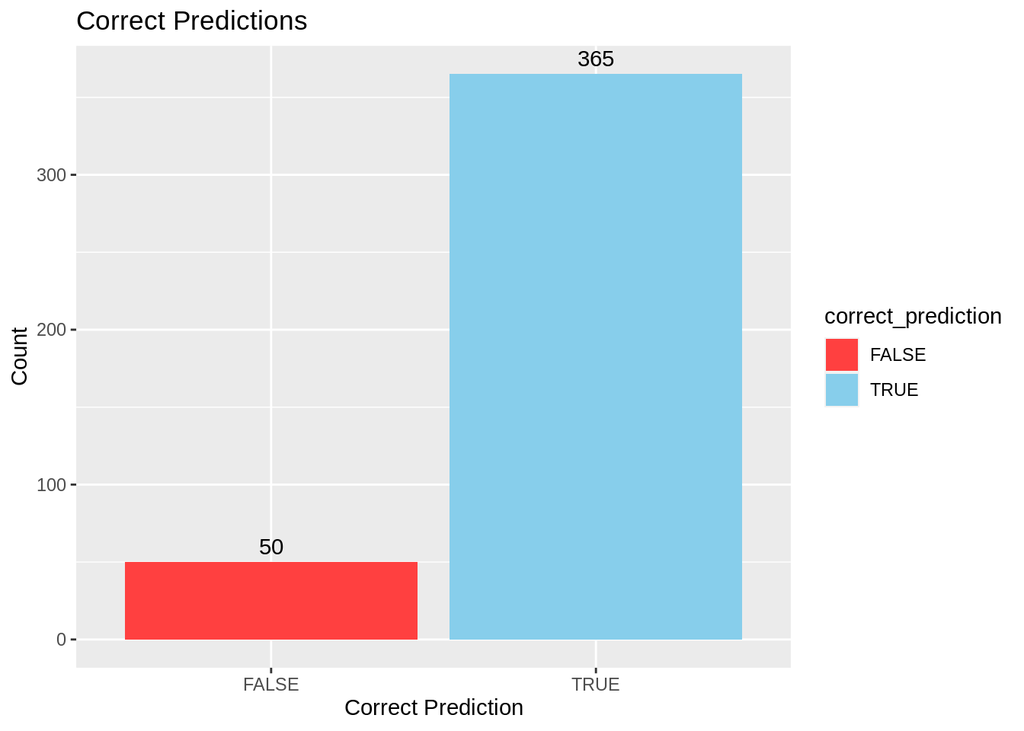

```r
# create plot
ggplot(output_table_matched, aes(x = factor(correct_prediction), fill = correct_prediction)) +
  geom_bar() +
  geom_text(stat = 'count', aes(label = ..count..), vjust = -0.5) +
  scale_fill_manual(values = c("TRUE" = "skyblue", "FALSE" = "brown1")) +
  labs(title = "Correct Predictions",
       x = "Correct Prediction",
       y = "Count")
```

Here we see that 365 of the 415 predictions were correct that’s around 88%

But sturgeon gives a confidence score the following is written in the README about the confidence score. score < 0.8: inconclusive result. 0.8 <= score < 0.95: confident result that the class is correct. score >= 0.95: high confident result that the class is correct.

Lets look at only the predictions that got a score above 0.8.

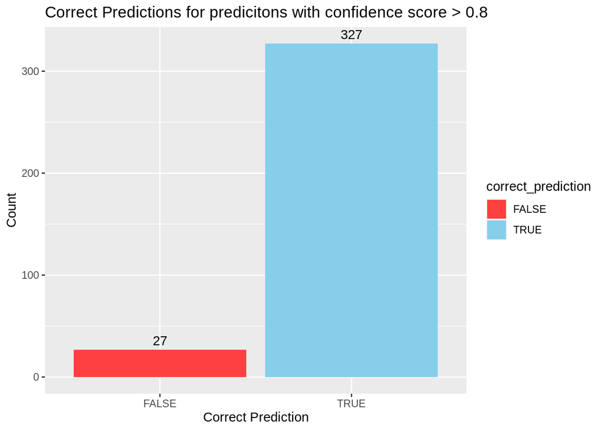

```r
output_table_matched %>% filter(confidence_score >= 0.8) %>%
  ggplot(aes(x = factor(correct_prediction), fill = correct_prediction)) +
  geom_bar() +
  geom_text(stat = 'count', aes(label = ..count..), vjust = -0.5) +
  scale_fill_manual(values = c("TRUE" = "skyblue", "FALSE" = "brown1")) +
  labs(title = "Correct Predictions for predicitons with confidence score > 0.8",
       x = "Correct Prediction",
       y = "Count")
```

The amount of wrong predictions almost halved, of the predictions with a confidence score above 0.8 about 92.5% were correct.

And then also look at the predictions that have a high confident result > 0.95

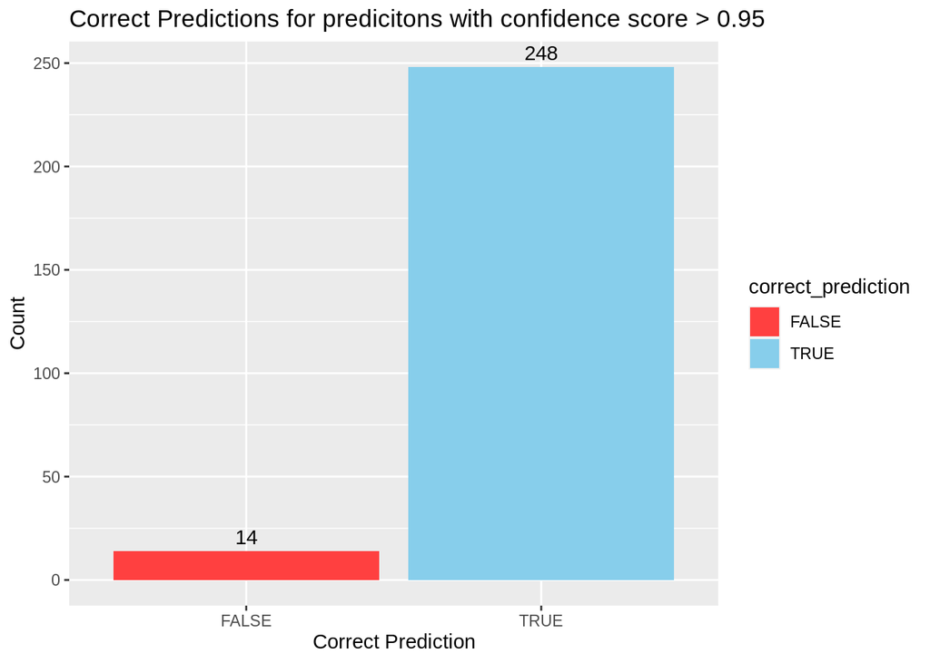

```r
output_table_matched %>% filter(confidence_score >= 0.95) %>%
  ggplot(aes(x = factor(correct_prediction), fill = correct_prediction)) +
  geom_bar() +
  geom_text(stat = 'count', aes(label = ..count..), vjust = -0.5) +
  scale_fill_manual(values = c("TRUE" = "skyblue", "FALSE" = "brown1")) +
  labs(title = "Correct Predictions for predicitons with confidence score > 0.95",
       x = "Correct Prediction",
       y = "Count")
```

The predictions with a confidence score above 0.95 are even more accurate with about 94,7% accuracy.

Lets take a look at the wrong predictions, lets see which reference diagnosis were guessed wrong the most

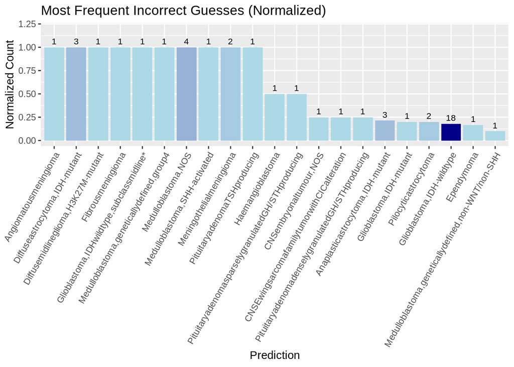

```r
# Filter incorrect predictions
incorrect_predictions <- output_table_matched %>% filter(correct_prediction == FALSE)

# Count the number of occurrences for each mistake
mistake_counts <- table(incorrect_predictions$reference_diagnosis.x)

# Count the total occurrences for each reference_diagnosis
total_counts <- table(output_table_matched$reference_diagnosis.x)

# Normalize the mistake counts by dividing by total occurrences
normalized_counts <- mistake_counts / total_counts[as.character(names(mistake_counts))]

# Create a data frame from the normalized_counts
sorted_data <- data.frame(
  prediction = names(normalized_counts),
  count = as.numeric(normalized_counts),
  total_wrong_guesses = as.numeric(mistake_counts)
)

# Sort the data frame by count in descending order
sorted_data <- sorted_data[order(-sorted_data$count), ]

# Set a threshold for the most frequent mistakes
threshold <- 0.1
top_mistakes <- sorted_data[sorted_data$count >= threshold, ]

# Reorder levels of the prediction factor based on count
top_mistakes$prediction <- factor(top_mistakes$prediction, levels = top_mistakes$prediction)

# Create plot
ggplot(top_mistakes, aes(x = prediction, y = count, fill = total_wrong_guesses, label = total_wrong_guesses)) +
  geom_bar(stat = "identity") +
  geom_text(vjust = -0.5, size = 3) +  # Add text labels for counts
  scale_fill_gradient(low = "lightblue", high = "darkblue") +  # Color scale for total wrong guesses
  theme(axis.text.x = element_text(angle = 60, hjust = 1)) +
  labs(
    title = "Most Frequent Incorrect Guesses (Normalized)",
    x = "Prediction",
    y = "Normalized Count",
    fill = "Total Wrong Guesses"
  ) +
  ylim(0, 1.2) +
  guides(fill = FALSE)
```

The data in the graph is normalized so bars that have a normalized count of 1 were never guessed correctly, but most of these only occur once. Glioblastoma, IDH-wildtype is guessed wrong most often but appears a hundred times in the dataset so its still guessed right more than 80% of the time. It’s also very much possible that some of the predictions that are marked as wrong might be correct but that something went wrong when translating the prediction to the reference_diagnosis form.

```r
# Function to get file size in bytes
get_file_size <- function(geo_accession) {
  pattern <- paste0(".*", geo_accession, ".*\\.bed\\.gz$")  # Regular expression pattern
  file_paths <- list.files("raw_data/GSE209865", pattern = pattern, full.names = TRUE)

  if (length(file_paths) > 0) {
    return(sum(fs::file_size(file_paths)))  # Sum of sizes if multiple files match the pattern
  } else {
    return(NA)  # Return NA if no matching file is found
  }
}


# Add a new column 'file_size_bytes' to the dataframe
output_table_matched$file_size_bytes <- sapply(output_table_matched$GEO_accession, get_file_size)
```

I noticed that the .bed files differed quite a lot in size, so i wondered whether confidence score or maybe the amount of correct prediction increased when the size of the file was bigger.

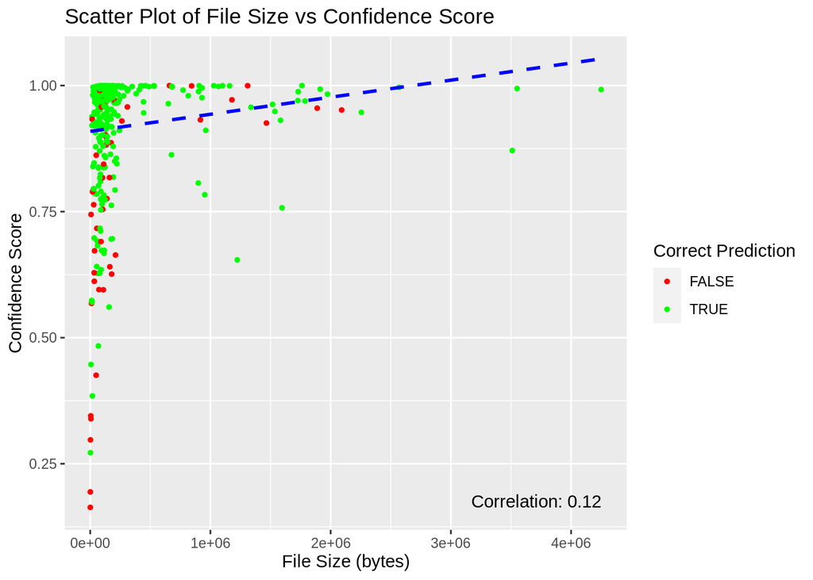

```r
# Calculate correlation coefficient
cor_coefficient <- cor(output_table_matched$file_size_bytes, output_table_matched$confidence_score)

# Create a scatter plot with correlation line
ggplot(output_table_matched, aes(x = file_size_bytes, y = confidence_score, color = correct_prediction)) +
  geom_point(size = 1) +
  scale_color_manual(values = c("TRUE" = "green", "FALSE" = "red")) +
  geom_smooth(method = "lm", se = FALSE, color = "blue", linetype = "dashed") +  # Add linear regression line
  labs(
    title = "Scatter Plot of File Size vs Confidence Score",
    x = "File Size (bytes)",
    y = "Confidence Score",
    color = "Correct Prediction"
  ) +
  annotate("text", x = max(output_table_matched$file_size_bytes), y = min(output_table_matched$confidence_score),
           label = paste("Correlation:", round(cor_coefficient, 2), sep = " "),
           hjust = 1, vjust = 0)
```

There is a small correlation between file size and confidence score, The predictions with very low confidence score are always small files.

### Running Sturgeon on hg19

In the sturgeon README is stated that the telomere-to-telomere reference genome (CHM13v2) is used in all of their work and they therefor encourage us to use this genome aswell thats why we lifted the data from hg19 to CHM13v2, but I wonder how the results change when we don’t use the lifted .bed files but just use the raw data.

So lets unzip the raw files.

```bash
# Create the destination directory if it doesn't exist
mkdir -p data/non_lifted-files

# Unzip and move the files
for file in raw_data/GSE209865/*.bed.gz; do
    gunzip -c "$file" > "data/non_lifted-files/$(basename "${file%.gz}")"
done
```

And run sturgeon on them!

```bash
cd sturgeon/
# move model to .pyenv/versions/3.7.12/lib/python3.7/site-packages/sturgeon/include/models
mv sturgeon/include/models/general_model.zip ../sturgeon/venv/lib/python3.7/site-packages/sturgeon/include/models

# Activate venv and conda env
conda activate sturgeon
source venv/bin/activate

sturgeon predict \
-i ../data/non_lifted-files/ \
-o ../results/run-with-raw_data/ \
--model-files ../sturgeon/venv/lib/python3.7/site-packages/sturgeon/include/models/general_model.zip \
--plot-results
```

I already showed how to read the data into R and add the meta data so I will do that on the background.

Lets take a look at the predictions from the raw_data run.

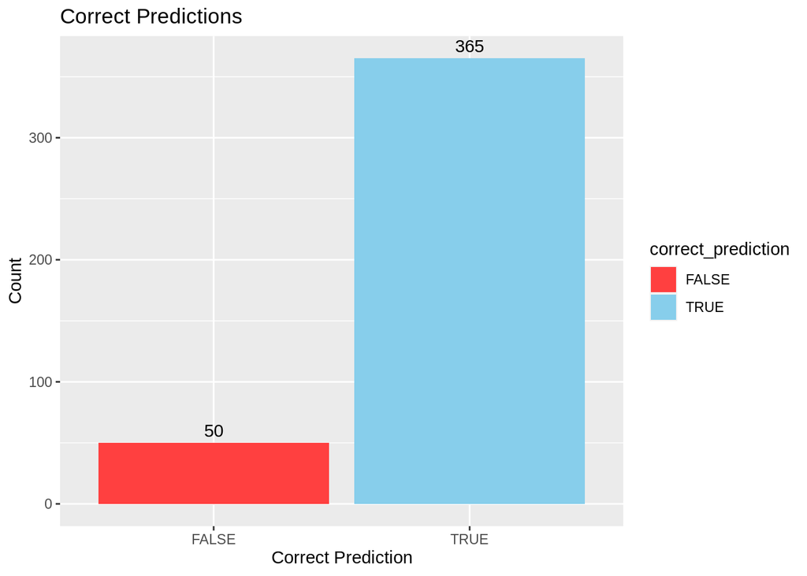

```r
# create plot
ggplot(output_table_matched_raw_data, aes(x = factor(correct_prediction), fill = correct_prediction)) +
  geom_bar() +
  geom_text(stat = 'count', aes(label = ..count..), vjust = -0.5) +
  scale_fill_manual(values = c("TRUE" = "skyblue", "FALSE" = "brown1")) +
  labs(title = "Correct Predictions",
       x = "Correct Prediction",
       y = "Count")
```

The amount of wrong predictions are exactly the same as the amount of wrong predictions when using the lifted files.

But maybe the predictions are made with less confidence

```r
output_table_matched$confidence_score %>% mean() - output_table_matched_raw_data$confidence_score %>% mean()
```

```
## [1] -0.0006995533
```

The mean confidence scores of the two runs are very close to each other and the raw_data mean is even a little higher.

Lets look at the distribution of the confidence scores

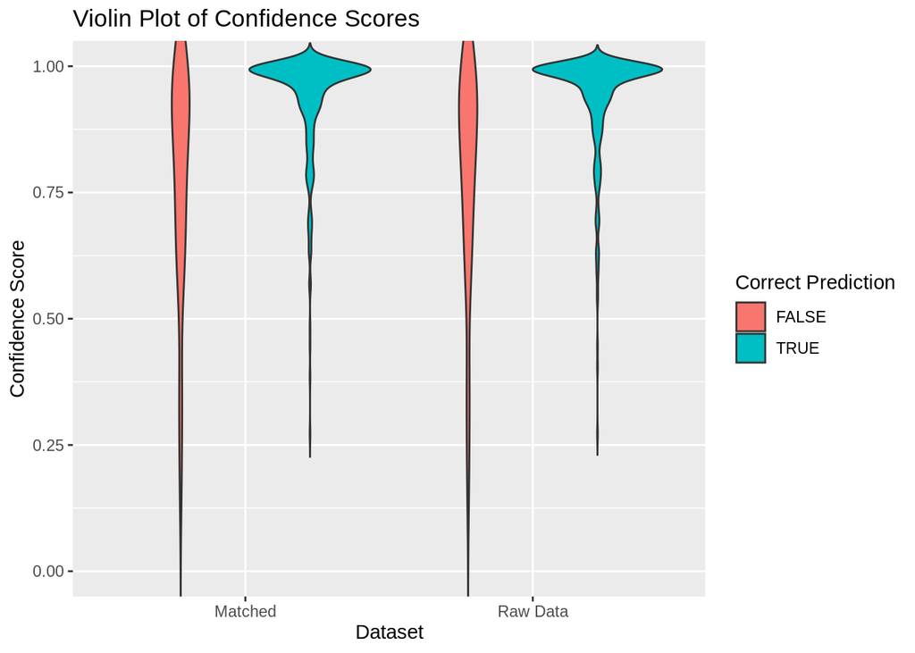

```r
# Combine data for plotting using dplyr::bind_rows
combined_data <- bind_rows(
  mutate(output_table_matched, Dataset = "Matched"),
  mutate(output_table_matched_raw_data, Dataset = "Raw Data")
)

ggplot(combined_data, aes(x = Dataset, y = confidence_score, fill = as.factor(correct_prediction))) +
  geom_violin(position = "dodge", trim = FALSE) +  # Adjust position for proper alignment
  labs(title = "Violin Plot of Confidence Scores",
       x = "Dataset",
       y = "Confidence Score",
       fill = "Correct Prediction") +
  coord_cartesian(ylim = c(0, 1))  # Set y-axis limits to 0 and 1
```

Let’s see if there were instances where there was something different guessed between the two runs.

```r
# Merge the dataframes based on GEO_accession with suffixes
merged_data <- merge(
  output_table_matched,
  output_table_matched_raw_data,
  by = "GEO_accession",
  suffixes = c("", "_raw")
)

# Filter rows where correct_prediction is different
differing_values <- merged_data[merged_data$correct_prediction != merged_data$correct_prediction_raw, ]

differing_values %>%
  select(GEO_accession, reference_diagnosis.x, matched_reference_diagnosis, matched_reference_diagnosis_raw)
```

```
##     GEO_accession     reference_diagnosis.x  matched_reference_diagnosis
## 48     GSM6402724                Ependymoma Pleomorphicxanthoastrocytoma
## 111    GSM6402787 Glioblastoma,IDH-wildtype    Glioblastoma,IDH-wildtype
##     matched_reference_diagnosis_raw
## 48                       Ependymoma
## 111         Glioblastoma,IDH-mutant
```

As we can see there are two instances where a different guess was made, once the run with the raw_files guessed the wrong Glioblastoma type and once the run with lifted files geussed the Ependymoma wrong.